# Analysis of Casco Bay OA data through 2018 – Revised Diurnal Graphics

Curtis C. Bohlen, Casco Bay Estuary Partnership

- Introduction
- Load Libraries
- Color Palette For Seasonal Displays
- Load Data
  - Establish Folder References
  - Dealing with Time Zones
  - Read the Data
  - Confirm Timezone Corrections
- pCO<sub>2</sub> Graphics (Temperature Corrected) by Season
  - Calculate pCO<sub>2</sub> Deviations
  - Run the GAMM
  - Generate Predictions from the Model
  - Create Ribbon Graphic
  - Alternate Graphic with Lines
- pH Graphics by Season
  - Calculate pH Deviations
  - Run the GAMM
  - Generate Predictions from the Model
  - Create Ribbon Graphic
  - Alternate Graphic with Lines

# Introduction

This notebook and related notebooks document analysis of data derived from a multi-year deployment of ocean acidification monitoring equipment at the Southern Maine Community College pier, in South Portland.

The monitoring set up was designed and operated by Joe Kelly, of UNH and his colleagues, on behalf of the Casco Bay Estuary Partnership. This was one of the first long-term OA monitoring facilities in the northeast, and was intended to test available technologies as well as gain operational experience working with acidification monitoring.

In this Notebook, we develop graphics looking at diurnal patterns of pCO<sub>2</sub> and pH, for Casco Bay Estuary partnership’s 2020 State of the Bay report. Companion R Notebooks in the Analysis Folder look in greater detail at model selection and uncertainty.

# Load Libraries

```r
library(tidyverse)  # includes readr, readxl and lubridate
library(lubridate)
library(mgcv)
```

```r
library(CBEPgraphics)
load_cbep_fonts()
theme_set(theme_cbep())
```

# Color Palette For Seasonal Displays

This is just a list, not a function like cbep_colors().

```r
season_palette = c(cbep_colors()[1],
                    cbep_colors()[4],
                    cbep_colors()[2],
                    'orange')
```

# Load Data

The following code loads data already cleaned and reorganized, via the “Data_Review_And_Filtering” R Notebook. The data includes a “temperature corrected” pCO2 value based on Takehashi et al. 2002.

> Takahashi, Taro & Sutherland, Stewart & Sweeney, Colm & Poisson, Alain & Metzl, Nicolas & Tilbrook, Bronte & Bates, Nicholas & Wanninkhof, Rik & Feely, Richard & Chris, Sabine & Olafsson, Jon & Nojiri, Yukihiro. (2002). Global sea-air CO2 flux based on climatological surface ocean pCO2, and seasonal biological and temperature effects. Deep Sea Research Part II: Topical Studies in Oceanography. 49. 1601-1622. 10.1016/S0967-0645(02)00003-6.

(See the “Data_Review_And_Filtering” R Notebook for details on why and how we calculated temperature-corrected pCO2 values.)

## Establish Folder References

```r
sibfldnm <- 'Derived_Data'
parent   <- dirname(getwd())
sibling  <- file.path(parent,sibfldnm)

fn    <- 'CascoBayOAData.csv'
fpath <- file.path(sibling,fn)
```

## Dealing with Time Zones

Note that the original time coordinate in the data received from UNH was in UTC, not local time. But read_csv() interprets times according to the locale, here Eastern Standard Time or Eastern Daylight Time, depending on time of year. I have not found an easy way to alter that behavior in read_csv(), but the force_tz() function from lubridate can fix it.

The primary reason we would want to correct the time coordinate to local time is that some version of local time is more appropriate for graphics showing the effect of time of day on acidification parameters. it is also important to make sure that as we work with other external data sources (e.g., tides, river discharge or weather) that all data uses the same time coordinate.

Note the series of datetime transformations here:

1. The datetime is generated on import assuming (implicitly) local time zone, which is incorrect. Our original data was in UTC.
2. The internal representation of the datetime object (POSIXct) is in seconds since the beginning of 1970, at Greenwich (GMT or UTC), so it is independent of timezone. The ‘tzone’ attribute determines how that time is represented externally, not how it is stored internally. So, if we just change the ‘tzone’ attribute, we only change the external representation of the (still incorrect) time that resulted from reading the data in with read_csv(). That would just lead to greater confusion. We need to change the INTERNAL representation of the time (as a number) while we also change the ‘tzone’ attribute. That is what lubridate’s force_tz() function does.
3. Finally, we need to convert to local time. Here, we can just change the ‘tzone’ attribute. (We use the structure() function for its convenience is a tidyverse pipeline.)

## Read the Data

```r
all_data <- read_csv(fpath,
                     col_types = cols(dd = col_integer(),
                                      doy = col_integer(),
                                      hh = col_integer(),
                                      mm = col_integer(),
                                      yyyy = col_integer())) %>%
  select(c(datetime, yyyy, mm, dd, hh, doy,
           temp, sal, do, ph, co2, co2_corr,
           omega_a, omega_c, TA_calc)) %>%
  mutate(datetime = force_tz(datetime, tzone = 'UTC')) %>%

  # "structure" function provides a way to specify or change attributes of an
  # existing object. But its main value here is that unlike attr() <-, it can
  # readily be incorporated into mutate(). (One COULD call
  # `attr<-(x, which, value)` directly, but structure is simpler....)
  mutate(stdtime   = structure(datetime, tzone = 'Etc/GMT+5'),
         localtime = structure(datetime, tzone = 'America/New_York')) %>%

  # We calculate all date and time components based on local standard time.
  mutate(yyyy  = as.numeric(format(stdtime, format = '%Y')),
         mm    = as.numeric(format(stdtime, format = '%m')),
         dd    = as.numeric(format(stdtime, format = '%d')),
         doy   = as.numeric(format(stdtime, format = '%j')),
         hh    = as.numeric(format(stdtime, format = '%H')),
         Month = factor(mm, levels=1:12, labels = month.abb)
         ) %>%
  mutate(Season = recode_factor(mm,
                                `1`  = 'Winter',
                                `2`  = 'Winter',
                                `3`  = 'Spring',
                                `4`  = 'Spring',
                                `5`  = 'Spring',
                                `6`  = 'Summer',
                                `7`  = 'Summer',
                                `8`  = 'Summer',
                                `9`  = 'Fall',
                                `10` = 'Fall',
                                `11` = 'Fall',
                                `12` = 'Winter'
                                ))
```

## Confirm Timezone Corrections

We quickly confirm that our efforts to adjust time coordiates had the intended effect.

We compare UTC, local standard time (UTC - 5 hours) and local time (including daylight savings time.) For April, standard time should be five hours “behind” UTC, while local time is in daylight savings, so should be four hours behind.

The first timestamp in the CSV file (‘CascoBayOAData.csv’) is 2015-4-23 15:00 (in UTC).

```r
knitr::kable(all_data %>%
  select(datetime, stdtime, localtime) %>%
  mutate_all(.funs = c(num=as.numeric)) %>%
  select(datetime, datetime_num, stdtime, stdtime_num, localtime, localtime_num) %>%
  head())
```

| datetime | datetime_num | stdtime | stdtime_num | localtime | localtime_num |
| --- | --- | --- | --- | --- | --- |
| 2015-04-23 15:00:00 | 1429801200 | 2015-04-23 10:00:00 | 1429801200 | 2015-04-23 11:00:00 | 1429801200 |
| 2015-04-23 16:00:00 | 1429804800 | 2015-04-23 11:00:00 | 1429804800 | 2015-04-23 12:00:00 | 1429804800 |
| 2015-04-23 17:00:00 | 1429808400 | 2015-04-23 12:00:00 | 1429808400 | 2015-04-23 13:00:00 | 1429808400 |
| 2015-04-23 18:00:00 | 1429812000 | 2015-04-23 13:00:00 | 1429812000 | 2015-04-23 14:00:00 | 1429812000 |
| 2015-04-23 19:00:00 | 1429815600 | 2015-04-23 14:00:00 | 1429815600 | 2015-04-23 15:00:00 | 1429815600 |
| 2015-04-23 20:00:00 | 1429819200 | 2015-04-23 15:00:00 | 1429819200 | 2015-04-23 16:00:00 | 1429819200 |

Note that:  
1. The first value of datetime matches the timestamp (in UTM) from the CSV file.  
2. The internal representation of the three different times remains the same, but the text representation differs.  
3. As required, stdtime is five hours behind datetime and localtime is four hours behind, as required.

# pCO<sub>2</sub> Graphics (Temperature Corrected) by Season

## Calculate pCO<sub>2</sub> Deviations

For temperature-corrected pCO<sub>2</sub>.

```r
diurnal_data <- all_data %>%
  group_by(yyyy, mm, dd) %>%
  # Calculate sample sizes for each day.
  mutate(co2_n      = sum(! is.na(co2)),
         co2_corr_n = sum(! is.na(co2_corr)),
         ph_n       = sum(! is.na(ph))) %>%

  # Calculate centered but not scaled values, day by day.
  mutate(co2_res      = scale(co2, scale = FALSE),
         co2_corr_res = scale(co2_corr, scale = FALSE),
         ph_res       = scale(ph, scale = FALSE)) %>%
  ungroup(yyyy, mm, dd) %>%

  # Replace data from any days with less than 20 hours of data with NA
  mutate(co2_res      = ifelse(co2_n>=20, co2_res, NA),
         co2_corr_res = ifelse(co2_corr_n>=20, co2_corr_res, NA),
         ph_res       = ifelse(ph_n>=20, ph_res, NA)) %>%

  # Delete unnecessary data to save space
  select(-contains('_n')) %>%
  select(c(stdtime, yyyy, Season, Month, dd, hh, co2_corr_res))
```

## Run the GAMM

The following takes ~ 15 minutes on a lightly loaded computer (Windows 10, 64 bit, Intel i5 processor, 2.4 GHz), and as long as 25 minutes when the machine had lots of other things going on.

```r
system.time(pco2_gam <- gamm(co2_corr_res ~  s(hh, by = Season, bs='cc', k=6),
                 correlation = corAR1(form = ~ 1 | Season),  # we run out of memory if we don't use a grouping
                 data = diurnal_data))
```

```
##    user  system elapsed
##  742.63  189.36  983.42
```

## Generate Predictions from the Model

```r
newdat <- expand.grid(hh = seq(0, 23),
                    Season = c('Winter', 'Spring', 'Summer', 'Fall'))
p <- predict(pco2_gam$gam, newdata = newdat, se.fit=TRUE)
newdat <- newdat %>%
  mutate(pred = p$fit, se = p$se.fit)
```

## Create Ribbon Graphic

The ribbon plot shows approximate 95% confidence intervals for the GAMM fits by season.

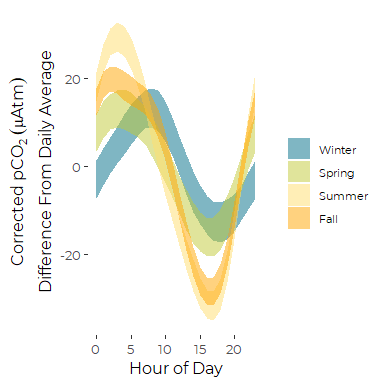

```r
ggplot(newdat, aes(x=hh, y=pred, color = Season)) + #geom_line() +
  geom_ribbon(aes(ymin = pred-(1.96*se),
                  ymax = pred+(1.96*se),
                  fill = Season), alpha = 0.5,
              color = NA) +

  theme_cbep(base_size= 12) +
  theme(legend.key.width = unit(0.25,"in"),
        legend.text      = element_text(size = 8)) +
  scale_fill_manual(values = season_palette, name = '') +

  xlab('Hour of Day') +
  ylab(expression (atop(Corrected~pCO[2]~(mu*Atm), Difference~From~Daily~Average)))
```

```r
ggsave('pco2_diurnal_seasons.pdf', device = cairo_pdf, width = 4, height = 4)
ggsave('pco2_diurnal_seasons.png', type = 'cairo', width = 4, height = 4)
```

## Alternate Graphic with Lines

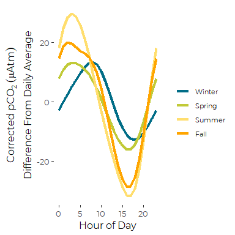

```r
ggplot(newdat, aes(x=hh, y=pred)) +
  geom_line(aes(y = pred, color = Season), lwd = 1.5) +

  theme_cbep(base_size= 12) +
  theme(legend.key.width = unit(0.25,"in"),
        legend.text      = element_text(size = 8)) +
  scale_color_manual(values = season_palette, name = '') +

  xlab('Hour of Day') +
  ylab(expression (atop(Corrected~pCO[2]~(mu*Atm), Difference~From~Daily~Average)))
```

```r
ggsave('pco2_diurnal_seasons_lines.pdf', device = cairo_pdf, width = 4, height = 4)
ggsave('pco2_diurnal_seasons_Lines.png', type = 'cairo', width = 4, height = 4)
```

# pH Graphics by Season

## Calculate pH Deviations

```r
diurnal_data <- all_data %>%
  group_by(yyyy, mm, dd) %>%
  # Calculate sample sizes for each day.
  mutate(co2_n      = sum(! is.na(co2)),
         co2_corr_n = sum(! is.na(co2_corr)),
         ph_n       = sum(! is.na(ph))) %>%

  # Calculate centered but not scaled values, day by day.
  mutate(co2_res      = scale(co2, scale = FALSE),
         co2_corr_res = scale(co2_corr, scale = FALSE),
         ph_res       = scale(ph, scale = FALSE)) %>%
  ungroup(yyyy, mm, dd) %>%

  # Replace data from any days with less than 20 hours of data with NA
  mutate(co2_res      = ifelse(co2_n>=20, co2_res, NA),
         co2_corr_res = ifelse(co2_corr_n>=20, co2_corr_res, NA),
         ph_res       = ifelse(ph_n>=20, ph_res, NA)) %>%

  # Delete unnecessary data to save memory
  select(-contains('_n')) %>%
  select(c(stdtime, yyyy, Season, Month, dd, hh, ph_res))
```

## Run the GAMM

The following takes ~ 7 minutes.

```r
system.time(ph_gam <- gamm(ph_res ~  s(hh, by = Season, bs='cc', k=6),
                 correlation = corAR1(form = ~ 1 | Season),  # we run out of memory if we don't use a grouping
                 data = diurnal_data))
```

```
##    user  system elapsed
##  339.64   97.32  451.50
```

## Generate Predictions from the Model

```r
newdat <- expand.grid(hh = seq(0, 23),
                    Season = c('Winter', 'Spring', 'Summer', 'Fall'))
p <- predict(ph_gam$gam, newdata = newdat, se.fit=TRUE)
newdat <- newdat %>%
  mutate(pred = p$fit, se = p$se.fit)
```

## Create Ribbon Graphic

The ribbon plots show approximate 95% confidence intervals for the GAMM fit by season.

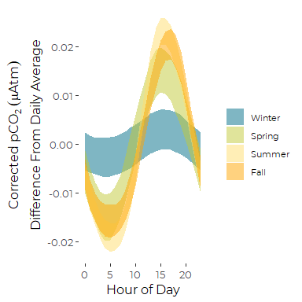

```r
ggplot(newdat, aes(x=hh, y=pred, color = Season)) + #geom_line() +
  geom_ribbon(aes(ymin = pred-(1.96*se),
                  ymax = pred+(1.96*se),
                  fill = Season), alpha = 0.5,
              color = NA) +

  theme_cbep(base_size= 12) +
  theme(legend.key.width = unit(0.25,"in"),
        legend.text      = element_text(size = 8)) +
  scale_fill_manual(values = season_palette, name = '') +

  xlab('Hour of Day') +
  ylab(expression (atop(Corrected~pCO[2]~(mu*Atm), Difference~From~Daily~Average)))
```

```r
ggsave('ph_diurnal_seasons.pdf', device = cairo_pdf, width = 4, height = 4)
ggsave('ph_diurnal_seasons.png', type = 'cairo', width = 4, height = 4)
```

## Alternate Graphic with Lines

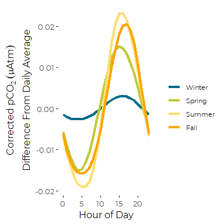

```r
ggplot(newdat, aes(x=hh, y=pred, color = Season)) + #geom_line() +
  geom_line(aes(y = pred, color = Season), lwd = 1.5) +

  theme_cbep(base_size= 12) +
  theme(legend.key.width = unit(0.25,"in"),
        legend.text      = element_text(size = 8)) +
  scale_color_manual(values = season_palette, name = '') +

  xlab('Hour of Day') +
  ylab(expression (atop(Corrected~pCO[2]~(mu*Atm), Difference~From~Daily~Average)))
```

```r
ggsave('ph_diurnal_seasons_lines.pdf', device = cairo_pdf, width = 4, height = 4)
ggsave('ph_diurnal_seasons_Lines.png', type = 'cairo', width = 4, height = 4)
```